# Effects of user category on the bike usage

## Investigation Overview

> In this investigation, I wanted to look at the some categories of bike users that could be affict on total usage. The main focus was on the four variables : duration, user type, birth year, member gender.

## Dataset Overview

> This data set includes information about individual rides made in a bike-sharing system covering the greater San Francisco Bay area. this is the website of the data: https://www.bikeshare.com/data/ Go bike system contain 16 columns and 183411 rows. I remved some columns that I did not used.

## The distribution of GoBike system

> To see what kind of users that use gobike and the most category of users that affect in using bike, I use univariate plot to show that.

```
Subscriber    163414
Customer       19801
Name: user_type, dtype: int64
```

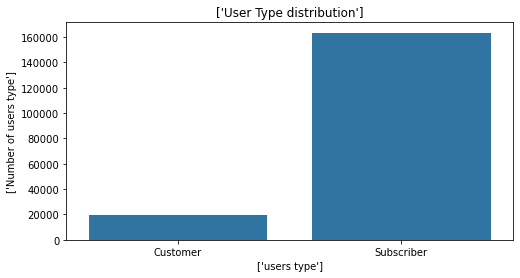

- As we see that most of the bike users are subscriber more than 160000 user

```
Male      130500
Female     40805
Other       3647
Name: member_gender, dtype: int64
```

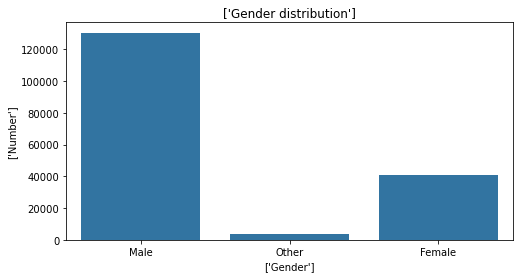

- more than 130000 of users are males

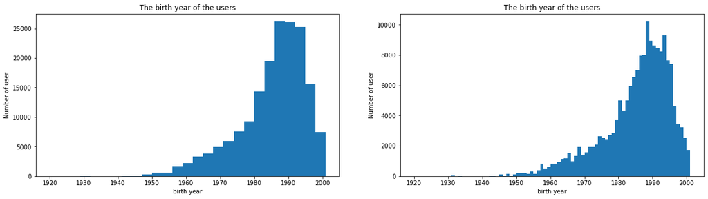

> the distribution seemed that skewed to left, when the year of birth older the usage gradually decrease, on the other hand, it stopped in 2001 the most users have a birth year between 1970 to 2000

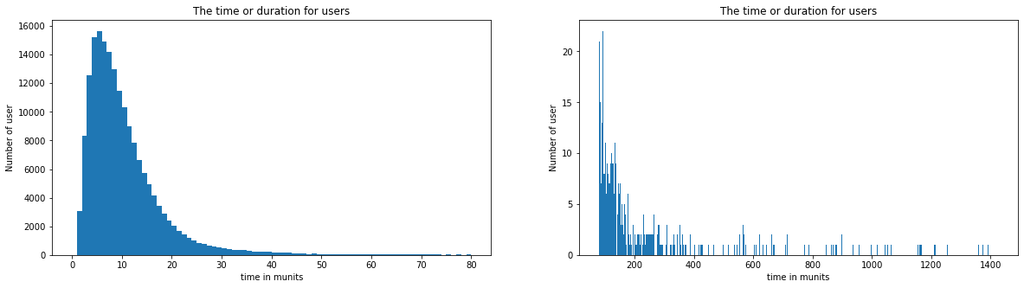

> to see the small numbers, I made 2 plot one from 0 to 100 (the large numbers) and another one from 100 to max '1400' ( the small numbers). we see that most duration between 0 to 20 minutes

## Duration Vs Year of birth

> This plot show the relation between the duration and year of birth and if the age or year of birth effect on the duration or not.

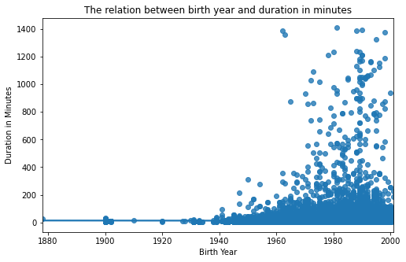

> It shows that there is a weak relation between the birth year and duration, I think befor the 1940 year the duration less than 200 munits and between 1940 and 1960 the duration less than 400 and after 1960 the duration range increase to become between 0 and 1400 minuts.

## User type Vs duration and user type Vs birth year

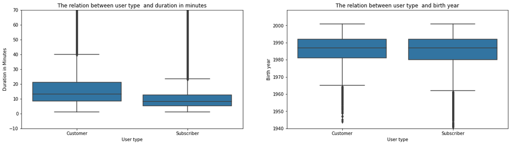

> - the first plot shows that the common duration between 0 to 40 minutes in customer and between 0 and 25 in subscriber
> - the second plot shows that both customer and subscriber common birth years are between 1967 and 2000

## The relation betweem Gender and user type

```
The subscriber male percentage to males : 0.9119310344827586
The subscriber female percentage to females : 0.8867050606543315
```

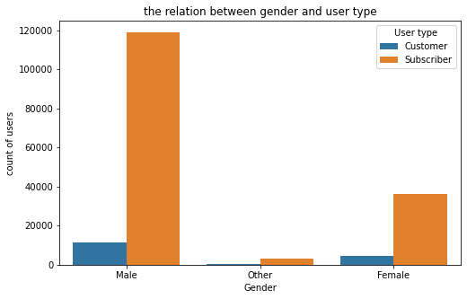

> - as we see in this plot that the percentage of males that subscrib is 91.2% and females percentage is 88.7%